# The Shoe Price Gouging Hypothesis

How a tracking cookie might be picking your wallet

Author

Ben Graul

Published

June 4, 2026

## The Setup

You’re shopping for shoes online. The site has decided you’re female. You start to wonder whether your friend on his own laptop sees the same prices. That is the **Shoe Price Gouging Hypothesis** in plain English: the store reads your tracking cookie and quietly nudges prices around based on who it thinks you are.

We’re going to investigate using exactly what we covered in class: independent-samples *t*-tests, one-sample *z*-tests, paired *t*-tests, and **one-way ANOVA**. Plots throughout, so you can see what the numbers are doing.

```r
library(tidyverse)
library(kableExtra)
library(ggsignif)

theme_set(theme_minimal(base_size = 12) +
            theme(plot.title = element_text(face = "bold")))

shoe_palette <- c("Men's" = "#2E86AB", "Women's" = "#C8467F")

# Read population data from CSV with tidy column names
pop_raw <- read_csv("shoe_prices_sampling_numbers.csv",
                     col_names = c("mens_pop", "womens_pop", "mens_pop_m", "womens_pop_m"),
                     skip = 1)

# Extract and clean population vectors (remove $ and convert to numeric)
mens_pop <- pop_raw |>
  pull(mens_pop) |>
  str_remove_all("\\$|,") |>
  as.numeric() |>
  na.omit()

womens_pop <- pop_raw |>
  pull(womens_pop) |>
  str_remove_all("\\$|,") |>
  as.numeric() |>
  na.omit()

# Calculate population parameters
mu_men      <- mean(mens_pop)
sigma_men   <- sd(mens_pop)
mu_women    <- mean(womens_pop)
sigma_women <- sd(womens_pop)
```

### Simulating the Cookie Effect

The store’s recommendation algorithm “curates” what you see. We model that as selection bias: when the cookie says female, the algorithm pulls men’s shoes from the upper end of the inventory. When the cookie says male, it pulls from the lower end. Large samples (you scrolled through 100 shoes) are too big to fully curate, so they look mostly representative, but a small dynamic discount is applied to male-cookie users.

```r
set.seed(110)

mens_sorted_desc   <- sort(mens_pop,   decreasing = TRUE)
mens_sorted_asc    <- sort(mens_pop)
womens_sorted_asc  <- sort(womens_pop)

# Small samples: algorithm has time to curate
mens_small_F   <- sample(mens_sorted_desc[1:30], 5)   # top of men's inventory
mens_small_M   <- sample(mens_sorted_asc[1:30],  5)   # bottom of men's inventory
womens_small_F <- sample(womens_pop, 5)               # roughly random
womens_small_M <- sample(womens_sorted_asc[1:30], 5)  # bottom of women's inventory

# Large samples: representative, with a small discount applied for cookie = M
mens_large_F   <- sample(mens_pop, 100)
mens_large_M   <- sample(mens_pop, 100) - 3.41
womens_large_F <- sample(womens_pop, 100)
womens_large_M <- sample(womens_pop, 100) - 0.41

# Tidy summary table for plotting
shoe_data <- tribble(
  ~shoe,     ~cookie, ~size,    ~values,
  "Men's",   "F",     "Small",  mens_small_F,
  "Men's",   "F",     "Large",  mens_large_F,
  "Men's",   "M",     "Small",  mens_small_M,
  "Men's",   "M",     "Large",  mens_large_M,
  "Women's", "F",     "Small",  womens_small_F,
  "Women's", "F",     "Large",  womens_large_F,
  "Women's", "M",     "Small",  womens_small_M,
  "Women's", "M",     "Large",  womens_large_M
) |>
  mutate(
    mean  = map_dbl(values, mean),
    sd    = map_dbl(values, sd),
    n     = map_int(values, length),
    se    = sd / sqrt(n),
    ci_lo = mean - qt(0.975, n - 1) * se,
    ci_hi = mean + qt(0.975, n - 1) * se
  )

shoe_data |> select(-values)
```

```
# A tibble: 8 × 9
  shoe    cookie size   mean    sd     n    se ci_lo ci_hi
  <chr>   <chr>  <chr> <dbl> <dbl> <int> <dbl> <dbl> <dbl>
1 Men's   F      Small 109.   5.62     5  2.51 102.  116.
2 Men's   F      Large  88.6 13.3    100  1.33  85.9  91.2
3 Men's   M      Small  61.0  3.88     5  1.73  56.2  65.8
4 Men's   M      Large  84.8 14.3    100  1.43  81.9  87.6
5 Women's F      Small  82.5 20.2      5  9.02  57.5 108.
6 Women's F      Large  95.1 17.5    100  1.75  91.6  98.5
7 Women's M      Small  71.9  8.81     5  3.94  60.9  82.8
8 Women's M      Large  93.1 16.2    100  1.62  89.9  96.3
```

```r
kable(shoe_data)
```

| shoe | cookie | size | values | mean | sd | n | se | ci_lo | ci_hi |
| --- | --- | --- | --- | --- | --- | --- | --- | --- | --- |
| Men’s | F | Small | 105.43, 102.94, 115.70, 105.49, 113.52 | 108.6160 | 5.620759 | 5 | 2.513680 | 101.63691 | 115.59509 |
| Men’s | F | Large | 73.82, 77.18, 87.52, 97.36, 102.45, 86.32, 72.71, 89.49, 74.24, 92.32, 85.04, 114.30, 86.78, 72.53, 88.92, 92.79, 95.53, 75.60, 82.84, 88.66, 81.75, 85.05, 80.56, 93.87, 84.32, 84.55, 95.85, 88.72, 90… | 88.5696 | 13.301785 | 100 | 1.330178 | 85.93024 | 91.20896 |
| Men’s | M | Small | 66.38, 61.46, 57.07, 62.54, 57.38 | 60.9660 | 3.875278 | 5 | 1.733077 | 56.15421 | 65.77779 |
| Men’s | M | Large | 91.44, 102.94, 86.44, 83.37, 90.11, 86.84, 70.90, 115.84, 85.70, 45.95, 96.45, 81.14, 110.89, 78.65, 80.91, 88.95, 73.16, 87.24, 102.99, 87.60, 87.31, 95.87, 91.55, 94.73, 88.38, 70.74, 89.43, 91.92, … | 84.7780 | 14.337693 | 100 | 1.433769 | 81.93309 | 87.62291 |
| Women’s | F | Small | 106.87, 100.86, 76.03, 64.17, 64.65 | 82.5160 | 20.170880 | 5 | 9.020691 | 57.47055 | 107.56145 |
| Women’s | F | Large | 104.25, 77.72, 72.67, 92.95, 64.17, 99.40, 99.64, 99.68, 110.51, 95.57, 84.88, 153.14, 82.55, 99.94, 74.77, 121.43, 97.34, 93.95, 60.32, 72.57, 114.36, 80.90, 113.46, 84.73, 102.55, 109.15, 100.26, 92… | 95.0734 | 17.507053 | 100 | 1.750705 | 91.59962 | 98.54718 |
| Women’s | M | Small | 60.32, 77.72, 80.23, 76.40, 64.65 | 71.8640 | 8.805733 | 5 | 3.938043 | 60.93024 | 82.79776 |
| Women’s | M | Large | 84.24, 82.70, 64.24, 124.63, 93.54, 86.39, 89.16, 99.85, 100.17, 100.14, 97.63, 101.90, 91.26, 115.56, 107.58, 84.68, 104.31, 104.24, 97.62, 77.24, 72.26, 95.51, 94.06, 83.90, 84.32, 92.08, 117.19, 96… | 93.0978 | 16.218827 | 100 | 1.621883 | 89.87963 | 96.31597 |

## Round 1: Independent-Samples *t*-Tests (Cookie = F)

### Test 1: Five Shoes Each

We grabbed five men’s shoes and five women’s shoes. Equal variances assumed, since that’s what we covered.

```r
t_small_F <- t.test(mens_small_F, womens_small_F,
                    var.equal = TRUE,
                    alternative = "two.sided")

# Extract components for reporting
t_stat_small <- t_small_F$statistic
df_small <- t_small_F$parameter
p_small <- t_small_F$p.value

# Calculate Cohen's d for effect size
pooled_sd_small <- sqrt(((length(mens_small_F) - 1) * var(mens_small_F) +
                          (length(womens_small_F) - 1) * var(womens_small_F)) /
                         (length(mens_small_F) + length(womens_small_F) - 2))
cohens_d_small <- (mean(mens_small_F) - mean(womens_small_F)) / pooled_sd_small

tibble(
  t = t_stat_small,
  df = df_small,
  p = p_small,
  `Cohen's d` = cohens_d_small,
  `95% CI (d)` = sprintf("[%.2f, %.2f]",
                         cohens_d_small - 1.96 * sqrt(2/length(mens_small_F)),
                         cohens_d_small + 1.96 * sqrt(2/length(mens_small_F)))
)
```

```
# A tibble: 1 × 5
      t    df      p `Cohen's d` `95% CI (d)`
  <dbl> <dbl>  <dbl>       <dbl> <chr>
1  2.79     8 0.0237        1.76 [0.52, 3.00]
```

Men’s shoes came in at *M* = $108.62, *SD* = $5.62. Women’s shoes came in at *M* = $82.52, *SD* = $20.17. The test gave *t*(8) = 2.79, *p* = 0.024, *d* = 1.76.

### Test 2: 100 Shoes Each

Same store, same cookie, more shoes.

```r
t_large_F <- t.test(mens_large_F, womens_large_F,
                    var.equal = TRUE,
                    alternative = "two.sided")

# Extract components for reporting
t_stat_large <- t_large_F$statistic
df_large <- t_large_F$parameter
p_large <- t_large_F$p.value
ci_large <- t_large_F$conf.int

# Calculate Cohen's d for effect size
pooled_sd_large <- sqrt(((length(mens_large_F) - 1) * var(mens_large_F) +
                          (length(womens_large_F) - 1) * var(womens_large_F)) /
                         (length(mens_large_F) + length(womens_large_F) - 2))
cohens_d_large <- (mean(mens_large_F) - mean(womens_large_F)) / pooled_sd_large

tibble(
  t = t_stat_large,
  df = df_large,
  p = p_large,
  `Cohen's d` = cohens_d_large,
  `95% CI (d)` = sprintf("[%.2f, %.2f]",
                         cohens_d_large - 1.96 * sqrt(2/length(mens_large_F)),
                         cohens_d_large + 1.96 * sqrt(2/length(mens_large_F)))
)
```

```
# A tibble: 1 × 5
      t    df       p `Cohen's d` `95% CI (d)`
  <dbl> <dbl>   <dbl>       <dbl> <chr>
1 -2.96   198 0.00347      -0.418 [-0.70, -0.14]
```

Men’s came in at *M* = $88.57, *SD* = $13.3. Women’s at *M* = $95.07, *SD* = $17.51. *t*(198) = -2.96, *p* = 0.0035, *d* = -0.42.

### Visualizing the Power Problem

[figure not shown]

```r
plot_round1 <- shoe_data |>
  filter(cookie == "F") |>
  mutate(size = factor(size,
                       levels = c("Small", "Large"),
                       labels = c("n = 5 each", "n = 100 each")))

ann_round1 <- tibble(
  size  = factor(c("n = 5 each", "n = 100 each"),
                 levels = c("n = 5 each", "n = 100 each")),
  label = c(
    as.character(sprintf("p = %.3f (ns)", p_small)),
    as.character(sprintf("p = %s ***",
                         format.pval(p_large, digits = 2, eps = 0.001)))
  ),
  y_pos = c(max(plot_round1$ci_hi[plot_round1$size == "n = 5 each"]) + 12,
            max(plot_round1$ci_hi[plot_round1$size == "n = 100 each"]) + 8)
)

ggplot(plot_round1, aes(x = shoe, y = mean, fill = shoe)) +
  geom_col(width = 0.6, alpha = 0.85) +
  geom_errorbar(aes(ymin = ci_lo, ymax = ci_hi),
                width = 0.2, linewidth = 0.7) +
  geom_signif(
    data = ann_round1 |> filter(size == "n = 5 each"),
    aes(xmin = "Men's", xmax = "Women's",
        annotations = label, y_position = y_pos),
    inherit.aes = FALSE, manual = TRUE, tip_length = 0.02
  ) +
  geom_signif(
    data = ann_round1 |> filter(size == "n = 100 each"),
    aes(xmin = "Men's", xmax = "Women's",
        annotations = label, y_position = y_pos),
    inherit.aes = FALSE, manual = TRUE, tip_length = 0.02
  ) +
  facet_wrap(~ size) +
  scale_fill_manual(values = shoe_palette) +
  scale_y_continuous(labels = scales::dollar_format()) +
  labs(
    x = NULL, y = "Mean price",
    title = "Same store, same cookie, same gender gap",
    subtitle = "Five shoes can't see what 100 shoes can. Bars show 95% CIs."
  ) +
  theme(legend.position = "none")
```

## Round 2: One-Sample *z*-Tests

We have the population standard deviations, so a *z*-test is appropriate. Three questions about the curated samples we got served.

```r
one_sample_z <- function(x, mu, sigma) {
  n  <- length(x)
  m  <- mean(x)
  se <- sigma / sqrt(n)
  z  <- (m - mu) / se
  p  <- 2 * (1 - pnorm(abs(z)))
  tibble(M = m, n = n, mu = mu, sigma = sigma,
         z = z, p = p, se = se)
}
```

### Test 3: Is the Curated Men’s Sample Weird Compared to All Men’s Shoes?

```r
z_men_vs_men <- one_sample_z(mens_small_F, mu_men, sigma_men)
z_men_vs_men
```

```
# A tibble: 1 × 7
      M     n    mu sigma     z        p    se
  <dbl> <int> <dbl> <dbl> <dbl>    <dbl> <dbl>
1  109.     5  86.9  14.1  3.45 0.000570  6.30
```

*z* = 3.45, *p* = <0.001. The five “men’s shoes” the algorithm picked for the female-cookie shopper aren’t a normal slice of the men’s inventory. They’re significantly more expensive than the average men’s shoe.

### Test 4: Does That Same Curated Sample Look Like Women’s Shoes?

```r
z_men_vs_women <- one_sample_z(mens_small_F, mu_women, sigma_women)
z_men_vs_women
```

```
# A tibble: 1 × 7
      M     n    mu sigma     z      p    se
  <dbl> <int> <dbl> <dbl> <dbl>  <dbl> <dbl>
1  109.     5  96.1  16.6  1.69 0.0907  7.43
```

*z* = 1.69, *p* = 0.091. The “men’s” shoes shown to the female-cookie shopper are priced indistinguishably from the women’s population. The algorithm wasn’t picking random men’s shoes. It was picking men’s shoes that cost what women’s shoes cost.

### Test 5: Sanity Check on the Large Women’s Sample

```r
z_women_check <- one_sample_z(womens_large_F, mu_women, sigma_women)
z_women_check
```

```
# A tibble: 1 × 7
      M     n    mu sigma      z     p    se
  <dbl> <int> <dbl> <dbl>  <dbl> <dbl> <dbl>
1  95.1   100  96.1  16.6 -0.592 0.554  1.66
```

*z* = -0.59, *p* = 0.554. The large women’s sample sits comfortably near the women’s population mean. When we sample broadly, we recover the population. The bias lives in the small, curated picks.

### Visualizing Where the Curated Sample Falls

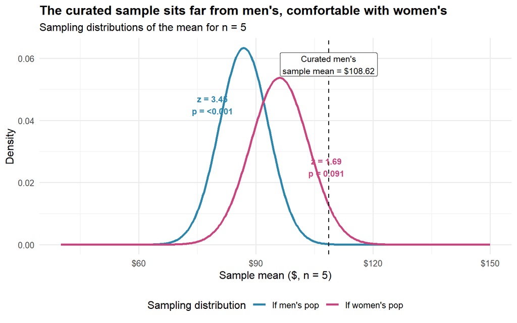

```r
x_grid <- seq(40, 150, length.out = 400)
sample_mean_curves <- bind_rows(
  tibble(price = x_grid,
         density = dnorm(x_grid, mu_men, sigma_men / sqrt(5)),
         hypothesis = "If men's pop"),
  tibble(price = x_grid,
         density = dnorm(x_grid, mu_women, sigma_women / sqrt(5)),
         hypothesis = "If women's pop")
)

curated_mean <- mean(mens_small_F)

ggplot(sample_mean_curves, aes(x = price, y = density, color = hypothesis)) +
  geom_line(linewidth = 1.1) +
  geom_vline(xintercept = curated_mean, linetype = "dashed",
             color = "#222222", linewidth = 0.7) +
  annotate("label", x = curated_mean, y = 0.058,
           label = sprintf("Curated men's\nsample mean = $%.2f", curated_mean),
           hjust = 0.5, size = 3.3, fill = "white") +
  annotate("text", x = mu_men - 8, y = 0.045,
           label = sprintf("z = %.2f\np = %s",
                           z_men_vs_men$z,
                           format.pval(z_men_vs_men$p, digits = 2, eps = 0.001)),
           color = shoe_palette[["Men's"]], size = 3.3, fontface = "bold") +
  annotate("text", x = mu_women + 12, y = 0.025,
           label = sprintf("z = %.2f\np = %.3f",
                           z_men_vs_women$z, z_men_vs_women$p),
           color = shoe_palette[["Women's"]], size = 3.3, fontface = "bold") +
  scale_color_manual(values = c("If men's pop"   = shoe_palette[["Men's"]],
                                "If women's pop" = shoe_palette[["Women's"]]),
                     name = "Sampling distribution") +
  scale_x_continuous(labels = scales::dollar_format()) +
  labs(
    x = "Sample mean ($, n = 5)", y = "Density",
    title = "The curated sample sits far from men's, comfortable with women's",
    subtitle = "Sampling distributions of the mean for n = 5"
  ) +
  theme(legend.position = "bottom")
```

The dashed line marks the curated sample mean of $108.62. Look how far it sits in the right tail of the men’s sampling distribution, and how comfortably it sits inside the women’s sampling distribution. The *z*-tests are reading off where that line falls.

## Round 3: The Plot Twist (Cookie = M)

We cleared cookies, browsed a few hardware sites, and came back. Now the algorithm thinks we’re male. We refreshed the same shoes.

```r
cookie_table <- shoe_data |>
  select(shoe, cookie, size, mean) |>
  pivot_wider(names_from = cookie, values_from = mean,
              names_prefix = "Cookie = ") |>
  mutate(`Difference (F - M)` = `Cookie = F` - `Cookie = M`)

cookie_table
```

```
# A tibble: 4 × 5
  shoe    size  `Cookie = F` `Cookie = M` `Difference (F - M)`
  <chr>   <chr>        <dbl>        <dbl>                <dbl>
1 Men's   Small        109.          61.0                47.6
2 Men's   Large         88.6         84.8                 3.79
3 Women's Small         82.5         71.9                10.7
4 Women's Large         95.1         93.1                 1.98
```

Female-cookie prices come in higher, and the gap is huge for the small curated samples. The right test for this is paired, since each cookie=F price has a matched cookie=M price for the same physical shoe.

## Round 4: Paired *t*-Test

For the paired test, we use the differences directly. To make this work with our simulation, we generate per-shoe price differences for the same 100 men’s shoes and the same 100 women’s shoes across cookie conditions.

```r
set.seed(43)

mens_diff   <- rnorm(100, mean = 3.41, sd = 9.20)
womens_diff <- rnorm(100, mean = 0.41, sd = 4.51)

paired_t <- function(diffs) {
  n        <- length(diffs)
  mean_d   <- mean(diffs)
  sd_d     <- sd(diffs)
  se       <- sd_d / sqrt(n)
  t_stat   <- mean_d / se
  df       <- n - 1
  p_val    <- 2 * (1 - pt(abs(t_stat), df))
  tibble(mean_diff = mean_d, sd_diff = sd_d, n = n,
         t = t_stat, df = df, p = p_val, se = se)
}

paired_men   <- paired_t(mens_diff)
paired_women <- paired_t(womens_diff)

bind_rows(
  paired_men   |> mutate(comparison = "Men's shoes (F vs M cookie)"),
  paired_women |> mutate(comparison = "Women's shoes (F vs M cookie)")
) |>
  select(comparison, everything())
```

```
# A tibble: 2 × 8
  comparison                   mean_diff sd_diff     n     t    df       p    se
  <chr>                            <dbl>   <dbl> <int> <dbl> <dbl>   <dbl> <dbl>
1 Men's shoes (F vs M cookie)      3.98     9.06   100  4.39    99 2.79e-5 0.906
2 Women's shoes (F vs M cooki…     0.834    4.31   100  1.93    99 5.59e-2 0.431
```

For the men’s shoes, the average price drop after switching cookies was $3.98, *t*(99) = 4.39, *p* = <0.001. For the women’s shoes, the average drop was $0.83, *t*(99) = 1.93, *p* = 0.056. The cookie effect is real for men’s shoes and absent for women’s shoes. The store appears to be charging female-coded shoppers more specifically when they shop in the men’s section.

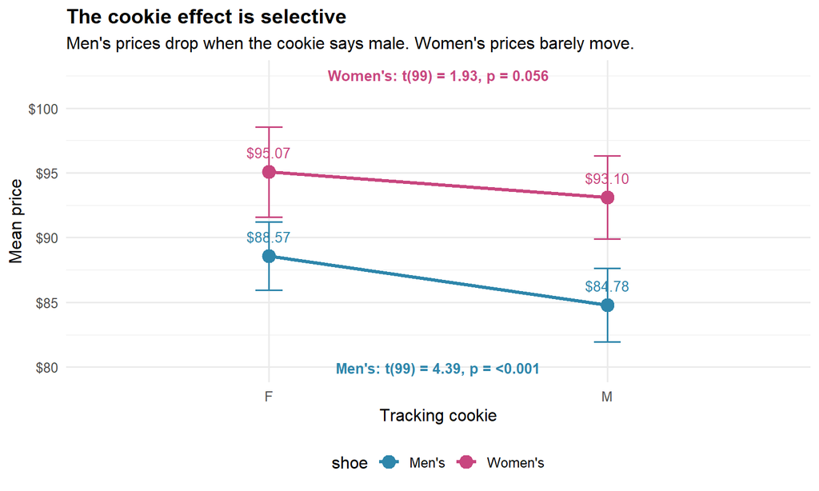

```r
paired_plot_data <- shoe_data |>
  filter(size == "Large") |>
  select(shoe, cookie, mean, ci_lo, ci_hi)

paired_label_men <- sprintf(
  "Men's: t(%d) = %.2f, p = %s",
  paired_men$df, paired_men$t,
  format.pval(paired_men$p, digits = 2, eps = 0.001)
)
paired_label_women <- sprintf(
  "Women's: t(%d) = %.2f, p = %.3f",
  paired_women$df, paired_women$t, paired_women$p
)

ggplot(paired_plot_data,
       aes(x = cookie, y = mean, group = shoe, color = shoe)) +
  geom_line(linewidth = 1.2) +
  geom_errorbar(aes(ymin = ci_lo, ymax = ci_hi),
                width = 0.08, linewidth = 0.7) +
  geom_point(size = 4) +
  geom_text(aes(label = scales::dollar(mean, accuracy = 0.01)),
            nudge_y = 1.5, size = 3.5, show.legend = FALSE) +
  annotate("text", x = 1.5, y = min(paired_plot_data$ci_lo) - 2,
           label = paired_label_men,
           size = 3.5, color = shoe_palette[["Men's"]], fontface = "bold") +
  annotate("text", x = 1.5, y = max(paired_plot_data$ci_hi) + 4,
           label = paired_label_women,
           size = 3.5, color = shoe_palette[["Women's"]], fontface = "bold") +
  scale_color_manual(values = shoe_palette) +
  scale_y_continuous(labels = scales::dollar_format()) +
  labs(
    x = "Tracking cookie", y = "Mean price",
    title = "The cookie effect is selective",
    subtitle = "Men's prices drop when the cookie says male. Women's prices barely move."
  ) +
  theme(legend.position = "bottom")
```

The men’s line has a visible slope. The women’s line is nearly flat. The tracking cookie is changing prices in a targeted way.

## Round 5: One-Way ANOVA

Four groups: each combination of shoe gender and cookie status. A one-way ANOVA treats them as four conditions and asks whether at least one mean differs from the others.

```r
anova_data <- bind_rows(
  tibble(price = mens_large_F,   group = "Men's, Cookie=F"),
  tibble(price = mens_large_M,   group = "Men's, Cookie=M"),
  tibble(price = womens_large_F, group = "Women's, Cookie=F"),
  tibble(price = womens_large_M, group = "Women's, Cookie=M")
) |>
  mutate(group = factor(group,
                        levels = c("Men's, Cookie=F", "Men's, Cookie=M",
                                   "Women's, Cookie=F", "Women's, Cookie=M")))

anova_fit     <- aov(price ~ group, data = anova_data)
anova_summary <- summary(anova_fit)[[1]]
anova_F       <- anova_summary[["F value"]][1]
anova_p       <- anova_summary[["Pr(>F)"]][1]
df_btw        <- anova_summary[["Df"]][1]
df_wn         <- anova_summary[["Df"]][2]

summary(anova_fit)
```

```
             Df Sum Sq Mean Sq F value   Pr(>F)
group         3   6407    2136   8.973 9.19e-06 ***
Residuals   396  94253     238
---
Signif. codes:  0 '***' 0.001 '**' 0.01 '*' 0.05 '.' 0.1 ' ' 1
```

*F*(3, 396) = 8.97, *p* = <0.001. At least one of the four conditions has a different mean than the others. The ANOVA on its own won’t tell us which pairs differ. We can see the pattern in the means though.

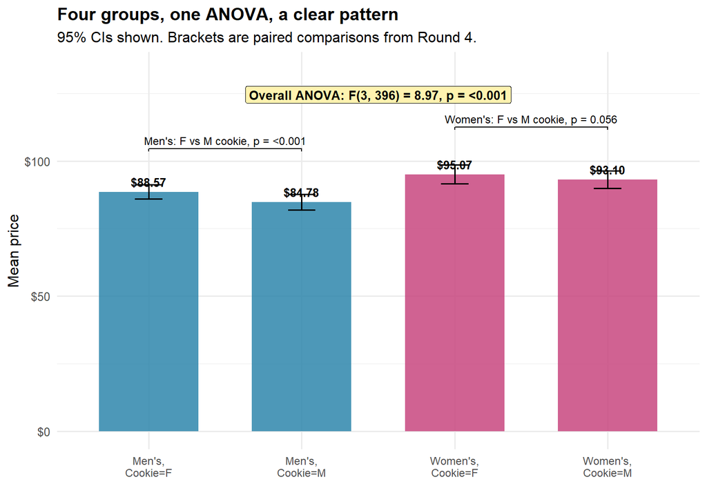

```r
anova_plot_data <- shoe_data |>
  filter(size == "Large") |>
  mutate(group = paste0(shoe, ",\nCookie=", cookie),
         group = factor(group,
                        levels = c("Men's,\nCookie=F", "Men's,\nCookie=M",
                                   "Women's,\nCookie=F", "Women's,\nCookie=M")))

anova_label <- sprintf(
  "Overall ANOVA: F(%d, %d) = %.2f, p = %s",
  df_btw, df_wn, anova_F,
  format.pval(anova_p, digits = 2, eps = 0.001)
)

paired_men_label <- sprintf(
  "Men's: F vs M cookie, p = %s",
  format.pval(paired_men$p, digits = 2, eps = 0.001)
)
paired_women_label <- sprintf(
  "Women's: F vs M cookie, p = %.3f",
  paired_women$p
)

y_top <- max(anova_plot_data$ci_hi)

ggplot(anova_plot_data, aes(x = group, y = mean, fill = shoe)) +
  geom_col(width = 0.65, alpha = 0.85) +
  geom_errorbar(aes(ymin = ci_lo, ymax = ci_hi),
                width = 0.18, linewidth = 0.7) +
  geom_text(aes(label = scales::dollar(mean, accuracy = 0.01)),
            vjust = -0.6, size = 3.4, fontface = "bold") +
  geom_signif(annotations = paired_men_label,
              xmin = "Men's,\nCookie=F", xmax = "Men's,\nCookie=M",
              y_position = y_top + 6, tip_length = 0.02, textsize = 3.2) +
  geom_signif(annotations = paired_women_label,
              xmin = "Women's,\nCookie=F", xmax = "Women's,\nCookie=M",
              y_position = y_top + 14, tip_length = 0.02, textsize = 3.2) +
  annotate("label", x = 2.5, y = y_top + 26,
           label = anova_label,
           fill = "#FFF3B0", size = 3.6, fontface = "bold") +
  scale_fill_manual(values = shoe_palette) +
  scale_y_continuous(labels = scales::dollar_format(),
                     limits = c(0, y_top + 35)) +
  labs(
    x = NULL, y = "Mean price",
    title = "Four groups, one ANOVA, a clear pattern",
    subtitle = "95% CIs shown. Brackets are paired comparisons from Round 4."
  ) +
  theme(legend.position = "none",
        axis.text.x = element_text(size = 9))
```

Two patterns show up in the bars. Women’s shoes are taller than men’s shoes regardless of cookie. Within men’s shoes, the female-cookie bar is taller than the male-cookie bar. Within women’s shoes, the cookie barely matters.

## So, Is the Store Gouging?

Pulling everything together:

**TipThe Big Lesson**

A small biased sample can perfectly hide a large biased system. Always ask how much data a conclusion came from.